# eda

Kino Watanabe

2025-10-07

```r
library(p8105.datasets)
library(tidyverse)
```

```r
knitr::opts_chunk$set(
  fig.width = 6,
  fig.asp = .6,
  out.width = "90%"
)

theme_set(theme_minimal() + theme(legend.position = "bottom"))

options(
  ggplot2.continuous.colour = "viridis",
  ggplot2.continuous.fill = "viridis"
)

scale_colour_discrete = scale_colour_viridis_d
scale_fill_discrete = scale_fill_viridis_d
```

Import the dataframe

- `lubridate` for data variables

```r
data(weather_df)

weather_df =
  weather_df |>
  mutate(
    month = lubridate::floor_date(date, unit = "month"))
```

Make plots

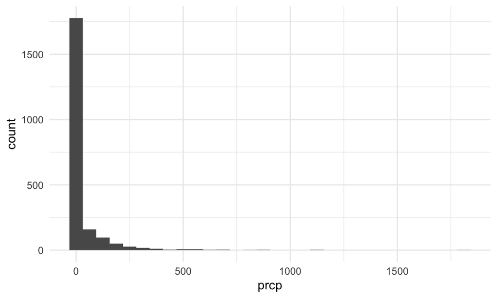

```r
weather_df |>
  ggplot(aes(x = prcp)) +
  geom_histogram()
```

Check on extreme variables – is this real? measurement error? * you could cross check online if that’s possible for context (NY central parl weather in 9/2021)

```r
weather_df |>
  filter(prcp >= 1000)
```

```
## # A tibble: 3 × 7
##   name           id          date        prcp  tmax  tmin month
##   <chr>          <chr>       <date>     <dbl> <dbl> <dbl> <date>
## 1 CentralPark_NY USW00094728 2021-08-21  1130  27.8  22.8 2021-08-01
## 2 CentralPark_NY USW00094728 2021-09-01  1811  25.6  17.2 2021-09-01
## 3 Molokai_HI     USW00022534 2022-12-18  1120  23.3  18.9 2022-12-01
```

Look at data again * Central park and Molokai – are on even grid structure * Waterhole is all over the place – what’a happening? WA is measuring temp is tenths of degrees celsius cs NY/HI measuring in F and converting/rounding to C

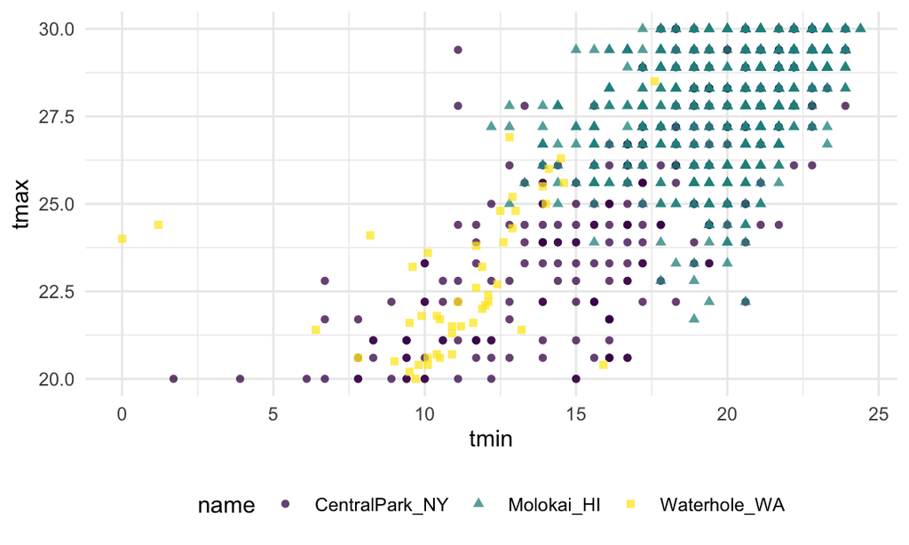

```r
weather_df |>
  filter(tmax >= 20, tmax <= 30) |>
  ggplot(aes(x = tmin, y = tmax, color = name, shape = name)) +
  geom_point(alpha = .75)
```

### Add groups

`group_by()` makes these groupings explicit so that they can be included in subsequent operations

```r
weather_df |>
  group_by(name, month)
```

```
## # A tibble: 2,190 × 7
## # Groups:   name, month [72]
##    name           id          date        prcp  tmax  tmin month
##    <chr>          <chr>       <date>     <dbl> <dbl> <dbl> <date>
##  1 CentralPark_NY USW00094728 2021-01-01   157   4.4   0.6 2021-01-01
##  2 CentralPark_NY USW00094728 2021-01-02    13  10.6   2.2 2021-01-01
##  3 CentralPark_NY USW00094728 2021-01-03    56   3.3   1.1 2021-01-01
##  4 CentralPark_NY USW00094728 2021-01-04     5   6.1   1.7 2021-01-01
##  5 CentralPark_NY USW00094728 2021-01-05     0   5.6   2.2 2021-01-01
##  6 CentralPark_NY USW00094728 2021-01-06     0   5     1.1 2021-01-01
##  7 CentralPark_NY USW00094728 2021-01-07     0   5    -1   2021-01-01
##  8 CentralPark_NY USW00094728 2021-01-08     0   2.8  -2.7 2021-01-01
##  9 CentralPark_NY USW00094728 2021-01-09     0   2.8  -4.3 2021-01-01
## 10 CentralPark_NY USW00094728 2021-01-10     0   5    -1.6 2021-01-01
## # ℹ 2,180 more rows
```

Group and count things

- Count obs for every month

```r
weather_df |>
  group_by(month) |>
  summarize(n_obs = n())
```

```
## # A tibble: 24 × 2
##    month      n_obs
##    <date>     <int>
##  1 2021-01-01    93
##  2 2021-02-01    84
##  3 2021-03-01    93
##  4 2021-04-01    90
##  5 2021-05-01    93
##  6 2021-06-01    90
##  7 2021-07-01    93
##  8 2021-08-01    93
##  9 2021-09-01    90
## 10 2021-10-01    93
## # ℹ 14 more rows
```

```r
weather_df |>
  group_by(name) |>
  summarize(n = n())
```

```
## # A tibble: 3 × 2
##   name               n
##   <chr>          <int>
## 1 CentralPark_NY   730
## 2 Molokai_HI       730
## 3 Waterhole_WA     730
```

```r
weather_df |>
  count(name)
```

```
## # A tibble: 3 × 2
##   name               n
##   <chr>          <int>
## 1 CentralPark_NY   730
## 2 Molokai_HI       730
## 3 Waterhole_WA     730
```

- Count obs for every month/name

```r
weather_df |>
  group_by(name, month) |>
  summarize(n = n())
```

```
## # A tibble: 72 × 3
## # Groups:   name [3]
##    name           month          n
##    <chr>          <date>     <int>
##  1 CentralPark_NY 2021-01-01    31
##  2 CentralPark_NY 2021-02-01    28
##  3 CentralPark_NY 2021-03-01    31
##  4 CentralPark_NY 2021-04-01    30
##  5 CentralPark_NY 2021-05-01    31
##  6 CentralPark_NY 2021-06-01    30
##  7 CentralPark_NY 2021-07-01    31
##  8 CentralPark_NY 2021-08-01    31
##  9 CentralPark_NY 2021-09-01    30
## 10 CentralPark_NY 2021-10-01    31
## # ℹ 62 more rows
```

- Count n distinct instances
- count the number of observations in each month and the number of distinct values of date in each month.

```r
weather_df |>
  group_by(month) |>
  summarize(
    n_obs = n(),
    n_days = n_distinct(date))
```

```
## # A tibble: 24 × 3
##    month      n_obs n_days
##    <date>     <int>  <int>
##  1 2021-01-01    93     31
##  2 2021-02-01    84     28
##  3 2021-03-01    93     31
##  4 2021-04-01    90     30
##  5 2021-05-01    93     31
##  6 2021-06-01    90     30
##  7 2021-07-01    93     31
##  8 2021-08-01    93     31
##  9 2021-09-01    90     30
## 10 2021-10-01    93     31
## # ℹ 14 more rows
```

Compute mean in each month * will NA if there’s a missing response

```r
weather_df |>
  group_by(name, month) |>
  summarize(
      mean_tmax = mean(tmax, na.rm = TRUE),
      median_tmin = median(tmin, na.rm = TRUE),
      sd_precp = sd(prcp, na.rm = TRUE)
      )
```

```
## # A tibble: 72 × 5
## # Groups:   name [3]
##    name           month      mean_tmax median_tmin sd_precp
##    <chr>          <date>         <dbl>       <dbl>    <dbl>
##  1 CentralPark_NY 2021-01-01      4.27       -0.5      47.3
##  2 CentralPark_NY 2021-02-01      3.87       -1.85     98.1
##  3 CentralPark_NY 2021-03-01     12.3         5        71.3
##  4 CentralPark_NY 2021-04-01     17.6         8.05     52.4
##  5 CentralPark_NY 2021-05-01     22.1        11.1      74.7
##  6 CentralPark_NY 2021-06-01     28.1        18.0      43.3
##  7 CentralPark_NY 2021-07-01     28.4        21.1     151.
##  8 CentralPark_NY 2021-08-01     28.8        22.2     236.
##  9 CentralPark_NY 2021-09-01     24.8        17.5     333.
## 10 CentralPark_NY 2021-10-01     19.9        13.9     151.
## # ℹ 62 more rows
```

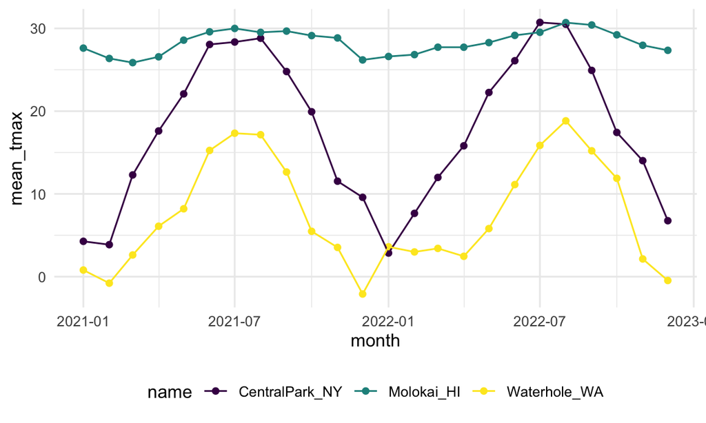

```r
weather_df |>
  group_by(name, month) |>
  summarize(
      mean_tmax = mean(tmax, na.rm = TRUE)) |>
  ggplot(aes(x = month, y = mean_tmax, color = name)) +
  geom_point() +
  geom_line() +
  theme(legend.position = "bottom")
```

Somtimes format results more nicely

```r
weather_df |>
  group_by(name, month) |>
  summarize(
      mean_tmax = mean(tmax, na.rm = TRUE)) |>
  pivot_wider(
    names_from = name,
    values_from = mean_tmax) |>
  knitr::kable(digits = 1)
```

| month | CentralPark_NY | Molokai_HI | Waterhole_WA |
| --- | --- | --- | --- |
| 2021-01-01 | 4.3 | 27.6 | 0.8 |
| 2021-02-01 | 3.9 | 26.4 | -0.8 |
| 2021-03-01 | 12.3 | 25.9 | 2.6 |
| 2021-04-01 | 17.6 | 26.6 | 6.1 |
| 2021-05-01 | 22.1 | 28.6 | 8.2 |
| 2021-06-01 | 28.1 | 29.6 | 15.3 |
| 2021-07-01 | 28.4 | 30.0 | 17.3 |
| 2021-08-01 | 28.8 | 29.5 | 17.2 |
| 2021-09-01 | 24.8 | 29.7 | 12.6 |
| 2021-10-01 | 19.9 | 29.1 | 5.5 |
| 2021-11-01 | 11.5 | 28.8 | 3.5 |
| 2021-12-01 | 9.6 | 26.2 | -2.1 |
| 2022-01-01 | 2.9 | 26.6 | 3.6 |
| 2022-02-01 | 7.7 | 26.8 | 3.0 |
| 2022-03-01 | 12.0 | 27.7 | 3.4 |
| 2022-04-01 | 15.8 | 27.7 | 2.5 |
| 2022-05-01 | 22.3 | 28.3 | 5.8 |
| 2022-06-01 | 26.1 | 29.2 | 11.1 |
| 2022-07-01 | 30.7 | 29.5 | 15.9 |
| 2022-08-01 | 30.5 | 30.7 | 18.8 |
| 2022-09-01 | 24.9 | 30.4 | 15.2 |
| 2022-10-01 | 17.4 | 29.2 | 11.9 |
| 2022-11-01 | 14.0 | 28.0 | 2.1 |
| 2022-12-01 | 6.8 | 27.3 | -0.5 |

### mutate with groups

- Summarizing collapses groups into single data points. In contrast, using mutate() in conjuntion with group_by() will retain all original data points and add new variables computed within groups.
- centered_tmax = tmax - mean_tmax) centers tmax around 0 (0 is avg) –> able to look at seasonal variation

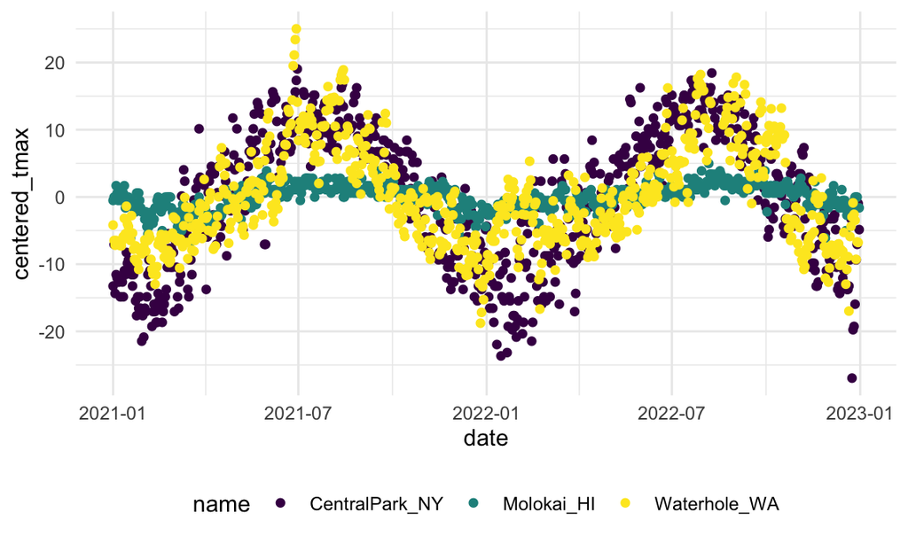

```r
weather_df |>
  group_by(name) |>
  mutate(
    mean_tmax = mean(tmax, na.rm = TRUE),
    centered_tmax = tmax - mean_tmax) |>
  ggplot(aes(x = date, y = centered_tmax, color = name)) +
    geom_point()
```

Look for cold days

```r
weather_df |>
  group_by(name, month) |>
  mutate(temp_rank = min_rank(tmax)) |>
  filter(temp_rank < 2)
```

```
## # A tibble: 92 × 8
## # Groups:   name, month [72]
##    name           id          date        prcp  tmax  tmin month      temp_rank
##    <chr>          <chr>       <date>     <dbl> <dbl> <dbl> <date>         <int>
##  1 CentralPark_NY USW00094728 2021-01-29     0  -3.8  -9.9 2021-01-01         1
##  2 CentralPark_NY USW00094728 2021-02-08     0  -1.6  -8.2 2021-02-01         1
##  3 CentralPark_NY USW00094728 2021-03-02     0   0.6  -6   2021-03-01         1
##  4 CentralPark_NY USW00094728 2021-04-02     0   3.9  -2.1 2021-04-01         1
##  5 CentralPark_NY USW00094728 2021-05-29   117  10.6   8.3 2021-05-01         1
##  6 CentralPark_NY USW00094728 2021-05-30   226  10.6   8.3 2021-05-01         1
##  7 CentralPark_NY USW00094728 2021-06-11     0  20.6  16.7 2021-06-01         1
##  8 CentralPark_NY USW00094728 2021-06-12     0  20.6  16.7 2021-06-01         1
##  9 CentralPark_NY USW00094728 2021-07-03    86  18.9  15   2021-07-01         1
## 10 CentralPark_NY USW00094728 2021-08-04     0  24.4  19.4 2021-08-01         1
## # ℹ 82 more rows
```

what about lags? * does my current value depend on my value yesterday/last visit? how much change was there btwn today and yesterday

```r
weather_df |>
  group_by(name) |>
  mutate(temp_change = tmax - lag(tmax))
```

```
## # A tibble: 2,190 × 8
## # Groups:   name [3]
##    name           id         date        prcp  tmax  tmin month      temp_change
##    <chr>          <chr>      <date>     <dbl> <dbl> <dbl> <date>           <dbl>
##  1 CentralPark_NY USW000947… 2021-01-01   157   4.4   0.6 2021-01-01      NA
##  2 CentralPark_NY USW000947… 2021-01-02    13  10.6   2.2 2021-01-01       6.2
##  3 CentralPark_NY USW000947… 2021-01-03    56   3.3   1.1 2021-01-01      -7.3
##  4 CentralPark_NY USW000947… 2021-01-04     5   6.1   1.7 2021-01-01       2.8
##  5 CentralPark_NY USW000947… 2021-01-05     0   5.6   2.2 2021-01-01      -0.5
##  6 CentralPark_NY USW000947… 2021-01-06     0   5     1.1 2021-01-01      -0.600
##  7 CentralPark_NY USW000947… 2021-01-07     0   5    -1   2021-01-01       0
##  8 CentralPark_NY USW000947… 2021-01-08     0   2.8  -2.7 2021-01-01      -2.2
##  9 CentralPark_NY USW000947… 2021-01-09     0   2.8  -4.3 2021-01-01       0
## 10 CentralPark_NY USW000947… 2021-01-10     0   5    -1.6 2021-01-01       2.2
## # ℹ 2,180 more rows
```

use the variables you create

```r
weather_df |>
  group_by(name) |>
  mutate(temp_change = tmax - lag(tmax)) |>
  summarize(
    temp_change_sd = sd(temp_change, na.rm = TRUE),
    temp_change_max = max(temp_change, na.rm = TRUE))
```

```
## # A tibble: 3 × 3
##   name           temp_change_sd temp_change_max
##   <chr>                   <dbl>           <dbl>
## 1 CentralPark_NY           4.43            12.2
## 2 Molokai_HI               1.24             5.6
## 3 Waterhole_WA             3.04            11.1
```

```r
weather_df |>
  group_by(name) |>
  mutate(temp_change = tmax - lag(tmax),
  change_rank = min_rank(desc(temp_change))) |>
  filter(
      change_rank < 2
  )
```

```
## # A tibble: 4 × 9
## # Groups:   name [3]
##   name     id    date        prcp  tmax  tmin month      temp_change change_rank
##   <chr>    <chr> <date>     <dbl> <dbl> <dbl> <date>           <dbl>       <int>
## 1 Central… USW0… 2022-03-06    15  20     6.1 2022-03-01        12.2           1
## 2 Molokai… USW0… 2021-01-19     0  27.8  21.1 2021-01-01         5.6           1
## 3 Molokai… USW0… 2022-11-29     0  27.8  19.4 2022-11-01         5.6           1
## 4 Waterho… USS0… 2022-12-22    76   1.5 -17.2 2022-12-01        11.1           1
```